# Lab 3 Live

Gregor Thomas

January 25, 2016

Load some packages

```r
packages = c("ggplot2", "arm", "broom", "reshape2", "tidyr", "dplyr")
lapply(packages, library, character.only = T)
```

Read in data and fit a model:

```r
wells = read.table("http://www.stat.columbia.edu/~gelman/arm/examples/arsenic/wells.dat")

wells$dist.log = log(wells$dist)

m_logd = glm(switch ~ dist.log, family = binomial(link = "logit"), data = wells)

display(m_logd)
```

```
## glm(formula = switch ~ dist.log, family = binomial(link = "logit"),
##     data = wells)
##             coef.est coef.se
## (Intercept)  1.02     0.16
## dist.log    -0.20     0.04
## ---
##   n = 3020, k = 2
##   residual deviance = 4097.3, null deviance = 4118.1 (difference = 20.8)
```

```r
p = ggplot(wells, aes(x = dist.log, y = switch)) +
    geom_point(position = position_jitter(height = 0.05),
               size = 0.8, alpha = 0.4) +
    stat_function(fun = function(x) {
        invlogit(coef(m_logd)[1] + coef(m_logd)[2] * x)
        })
```

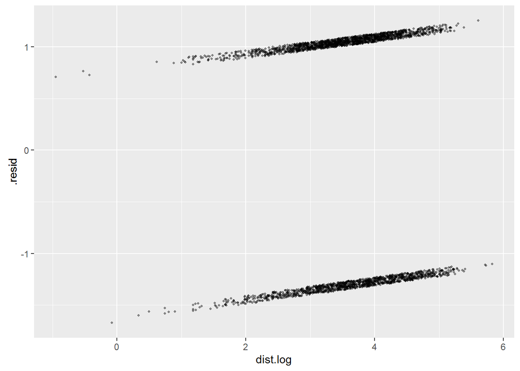

```r
well_a = augment(m_logd)
ggplot(well_a, aes(x = dist.log, y = .resid)) +
    geom_point(position = position_jitter(height = 0.1), size = 0.8, alpha = 0.4)
```

Binned residual plot

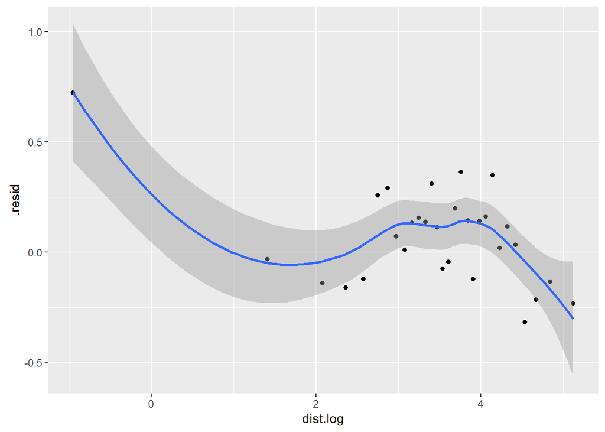

```r
well_bin = well_a %>%
    mutate(
        q_group = cut(dist.log,
                      breaks = quantile(dist.log, seq(0, 1, length.out = 30), include.lowest = TRUE))
    ) %>%
    group_by(q_group) %>%
    summarize(.resid = mean(.resid),
              dist.log = mean(dist.log))

ggplot(well_bin, aes(x = dist.log, y = .resid)) +
    geom_point() +
    geom_smooth()
```

```r
wells$dist100 = wells$dist / 100
mod = glm(switch ~ dist100 + log(arsenic), data = wells,
          family = binomial)
display(mod)
```

```
## glm(formula = switch ~ dist100 + log(arsenic), family = binomial,
##     data = wells)
##              coef.est coef.se
## (Intercept)   0.53     0.06
## dist100      -0.98     0.11
## log(arsenic)  0.88     0.07
## ---
##   n = 3020, k = 3
##   residual deviance = 3898.4, null deviance = 4118.1 (difference = 219.7)
```

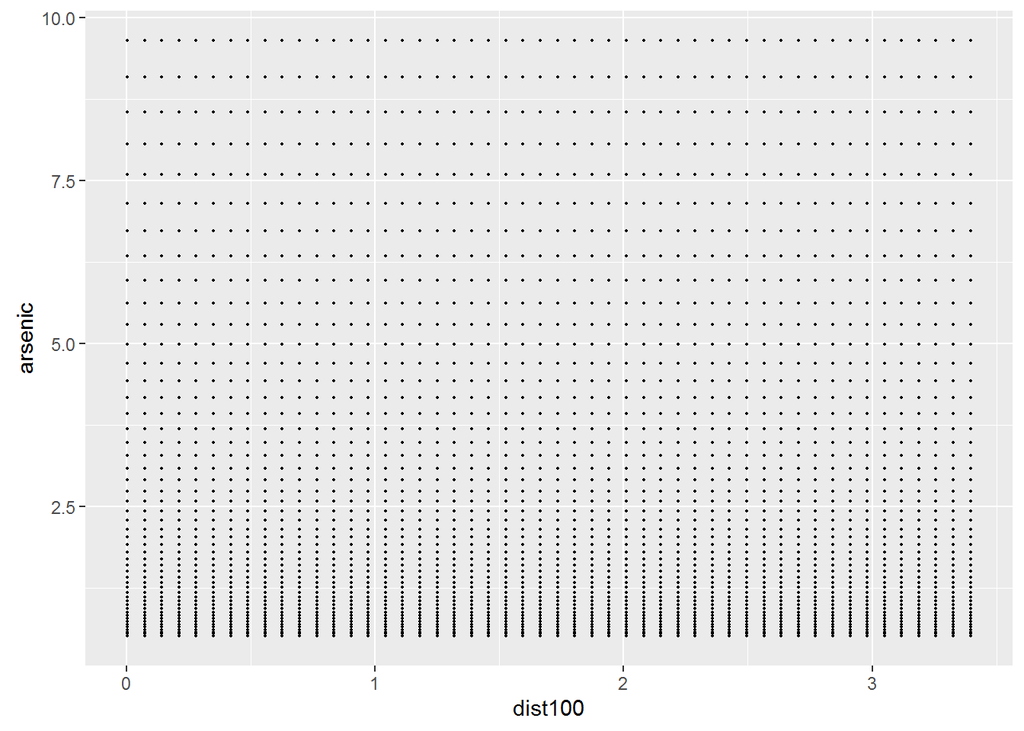

```r
fill_in = function(x, n = 50) {
    seq(from = min(x), to = max(x), length.out = n)
}

new_well = expand.grid(
    dist100 = fill_in(wells$dist100),
    arsenic = exp(fill_in(log(wells$arsenic)))
)

nw_plot = ggplot(new_well, aes(x = dist100, y = arsenic)) +
    geom_point(size = 0.3)

nw_plot
```

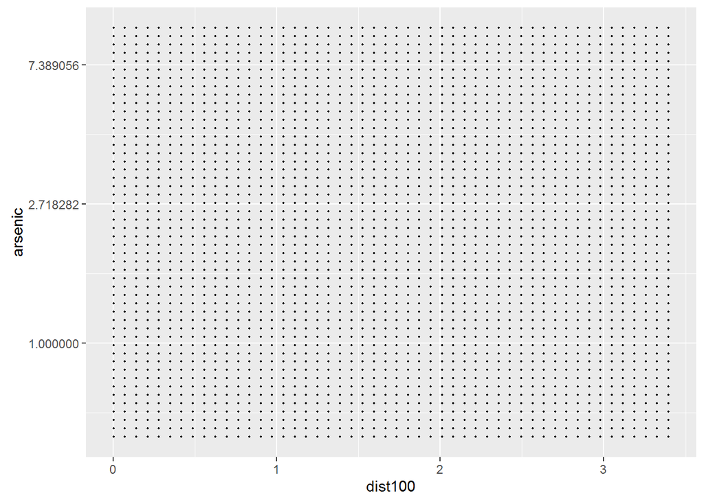

```r
nw_plot + scale_y_continuous(trans = "log")
```

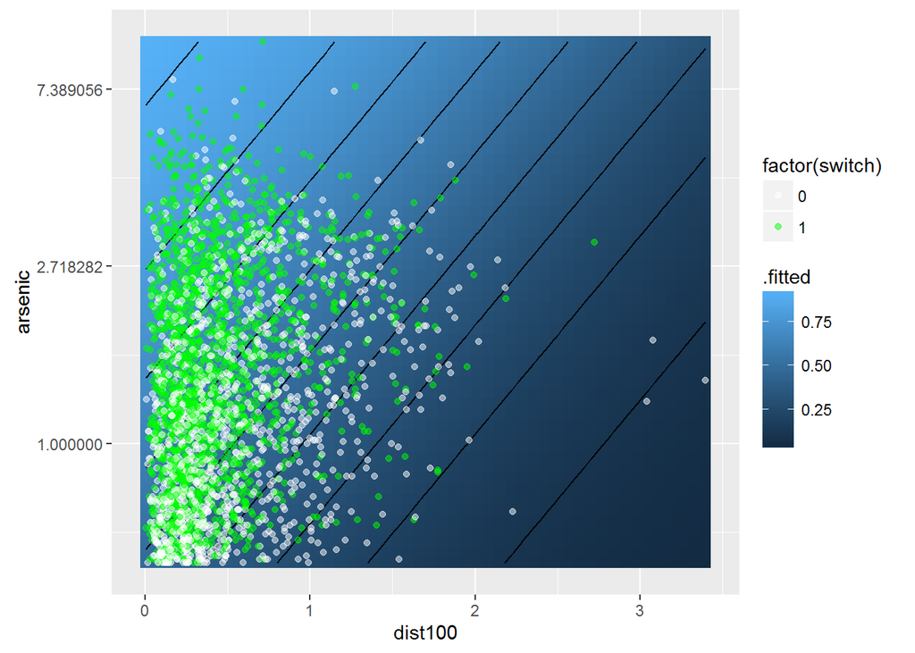

```r
pred = augment(mod, newdata = new_well, type.predict = "response")

ggplot(pred, aes(x = dist100, y = arsenic)) +
    geom_tile(aes(fill = .fitted)) +
    stat_contour(aes(z = .fitted), colour = "black") +
    scale_y_continuous(trans = "log") +
    geom_point(data = wells, aes(colour = factor(switch)), alpha =  0.5) +
    scale_color_manual(values = c("white", "green"))
```

To make the “confusion matrix” faceted plot we need to turn the model’s probability-scale predictions into binary 1-0 prdictions. Because we’re not doing any fancy adjustments, we’ll just round the fitted values to the nearest 1 or 0.

```r
well_a2 = augment(mod, type.predict = "response")
well_a2$predicted = round(well_a2$.fitted)

# this is the 'confusion matrix'
# 0,0 and 1,1 are the correct predictions
# the 0,1 and 1,0 are the incorrect predictions
table(well_a2$switch, well_a2$predicted)
```

```
##
##        0    1
##   0  536  747
##   1  370 1367
```

The “true” values are in the `switch` column, and the predicted values are in the cleverly named `predicted` column. For our confusion matrix plot we need to facet by these two variables:

[figure not shown]

```r
ggplot(pred, aes(x = dist100, y = arsenic)) +
   scale_y_continuous(trans = "log") +
    geom_tile(aes(fill = .fitted)) +
        stat_contour(aes(z = .fitted), colour = "black") +
    geom_point(data = well_a2,
               aes(colour = factor(switch == predicted,
                                   labels = c("Incorrect", "Correct")),
                   y = exp(log.arsenic.)),
               alpha =  0.5) +
    scale_color_manual(values = c("firebrick3", "green"),
                       name = "Model Performance") +
    facet_grid(switch ~ predicted)
```

## Regular Expressions

Some sample strings:

```r
library(stringr)
counties = c("Adams", "Asotin", "Benton", "Chelan", "Clallam", "Clark",
"Columbia", "Cowlitz", "Douglas", "Ferry", "Franklin", "Garfield",
"Grant", "Grays Harbor", "Island", "Jefferson", "King", "Kitsap",
"Kittitas", "Klickitat", "Lewis", "Lincoln", "Mason", "Okanogan",
"Pacific", "Pend Oreille", "Pierce", "San Juan", "Skagit", "Skamania",
"Snohomish", "Spokane", "Stevens", "Thurston", "Wahkiakum", "Walla Walla",
"Whatcom", "Whitman", "Yakima")
```

`str_detect` returns true or false based on whether it finds the pattern in each string.

```r
# which counties have a lowercase 'a'?
str_detect(counties, pattern = "a")
```

```
##  [1]  TRUE FALSE FALSE  TRUE  TRUE  TRUE  TRUE FALSE  TRUE FALSE  TRUE
## [12]  TRUE  TRUE  TRUE  TRUE FALSE FALSE  TRUE  TRUE  TRUE FALSE FALSE
## [23]  TRUE  TRUE  TRUE FALSE FALSE  TRUE  TRUE  TRUE FALSE  TRUE FALSE
## [34] FALSE  TRUE  TRUE  TRUE  TRUE  TRUE
```

```r
# the logical vector isn't super useful, instead let's
# subset the vector by the matches
counties[str_detect(counties, pattern = "a")]
```

```
##  [1] "Adams"        "Chelan"       "Clallam"      "Clark"
##  [5] "Columbia"     "Douglas"      "Franklin"     "Garfield"
##  [9] "Grant"        "Grays Harbor" "Island"       "Kitsap"
## [13] "Kittitas"     "Klickitat"    "Mason"        "Okanogan"
## [17] "Pacific"      "San Juan"     "Skagit"       "Skamania"
## [21] "Spokane"      "Wahkiakum"    "Walla Walla"  "Whatcom"
## [25] "Whitman"      "Yakima"
```

```r
# counties that have an 'a' followed by an 's'
counties[str_detect(counties, pattern = "as")]
```

```
## [1] "Douglas"  "Kittitas" "Mason"
```

```r
# a really long pattern (case matters!):
counties[str_detect(counties, pattern = "Skagi")]
```

```
## [1] "Skagit"
```

`str_replace` is the *find/replace* command. Note that I am **not** assigning the results so as to leave the original vector intact.

```r
# replace 'a' with space ' '
str_replace(counties, pattern = "a", replacement = " ")
```

```
##  [1] "Ad ms"        "Asotin"       "Benton"       "Chel n"
##  [5] "Cl llam"      "Cl rk"        "Columbi "     "Cowlitz"
##  [9] "Dougl s"      "Ferry"        "Fr nklin"     "G rfield"
## [13] "Gr nt"        "Gr ys Harbor" "Isl nd"       "Jefferson"
## [17] "King"         "Kits p"       "Kittit s"     "Klickit t"
## [21] "Lewis"        "Lincoln"      "M son"        "Ok nogan"
## [25] "P cific"      "Pend Oreille" "Pierce"       "S n Juan"
## [29] "Sk git"       "Sk mania"     "Snohomish"    "Spok ne"
## [33] "Stevens"      "Thurston"     "W hkiakum"    "W lla Walla"
## [37] "Wh tcom"      "Whitm n"      "Y kima"
```

```r
# str_replace only replaces the *first* instance per string
# to get them all, use str_replace_all
str_replace_all(counties, pattern = "a", replacement = " ")
```

```
##  [1] "Ad ms"        "Asotin"       "Benton"       "Chel n"
##  [5] "Cl ll m"      "Cl rk"        "Columbi "     "Cowlitz"
##  [9] "Dougl s"      "Ferry"        "Fr nklin"     "G rfield"
## [13] "Gr nt"        "Gr ys H rbor" "Isl nd"       "Jefferson"
## [17] "King"         "Kits p"       "Kittit s"     "Klickit t"
## [21] "Lewis"        "Lincoln"      "M son"        "Ok nog n"
## [25] "P cific"      "Pend Oreille" "Pierce"       "S n Ju n"
## [29] "Sk git"       "Sk m ni "     "Snohomish"    "Spok ne"
## [33] "Stevens"      "Thurston"     "W hki kum"    "W ll  W ll "
## [37] "Wh tcom"      "Whitm n"      "Y kim "
```

```r
str_replace(counties, pattern = "fer", replacement = " FER was here ")
```

```
##  [1] "Adams"                "Asotin"               "Benton"
##  [4] "Chelan"               "Clallam"              "Clark"
##  [7] "Columbia"             "Cowlitz"              "Douglas"
## [10] "Ferry"                "Franklin"             "Garfield"
## [13] "Grant"                "Grays Harbor"         "Island"
## [16] "Jef FER was here son" "King"                 "Kitsap"
## [19] "Kittitas"             "Klickitat"            "Lewis"
## [22] "Lincoln"              "Mason"                "Okanogan"
## [25] "Pacific"              "Pend Oreille"         "Pierce"
## [28] "San Juan"             "Skagit"               "Skamania"
## [31] "Snohomish"            "Spokane"              "Stevens"
## [34] "Thurston"             "Wahkiakum"            "Walla Walla"
## [37] "Whatcom"              "Whitman"              "Yakima"
```

```r
# replace all spaces with nothing (delete spaces)
str_replace_all(counties, pattern = " ", replacement = "")
```

```
##  [1] "Adams"       "Asotin"      "Benton"      "Chelan"      "Clallam"
##  [6] "Clark"       "Columbia"    "Cowlitz"     "Douglas"     "Ferry"
## [11] "Franklin"    "Garfield"    "Grant"       "GraysHarbor" "Island"
## [16] "Jefferson"   "King"        "Kitsap"      "Kittitas"    "Klickitat"
## [21] "Lewis"       "Lincoln"     "Mason"       "Okanogan"    "Pacific"
## [26] "PendOreille" "Pierce"      "SanJuan"     "Skagit"      "Skamania"
## [31] "Snohomish"   "Spokane"     "Stevens"     "Thurston"    "Wahkiakum"
## [36] "WallaWalla"  "Whatcom"     "Whitman"     "Yakima"
```

Special characters! There are lots of special characters, [this cheatsheet](http://www.cheatography.com/davechild/cheat-sheets/regular-expressions/) is helpful.

```r
# '^' is the start of the string
# '^A' will match strings that start with 'A'
counties[str_detect(counties, pattern = "^A")]
```

```
## [1] "Adams"  "Asotin"
```

```r
# '$' is the end of the string
# 's$' matches strings that end with s
counties[str_detect(counties, pattern = "s$")]
```

```
## [1] "Adams"    "Douglas"  "Kittitas" "Lewis"    "Stevens"
```

```r
# '.' matches any single character
counties[str_detect(counties, pattern = "o.o")]
```

```
## [1] "Snohomish"
```

```r
# First four characters:
str_extract(counties, pattern = "^....")
```

```
##  [1] "Adam" "Asot" "Bent" "Chel" "Clal" "Clar" "Colu" "Cowl" "Doug" "Ferr"
## [11] "Fran" "Garf" "Gran" "Gray" "Isla" "Jeff" "King" "Kits" "Kitt" "Klic"
## [21] "Lewi" "Linc" "Maso" "Okan" "Paci" "Pend" "Pier" "San " "Skag" "Skam"
## [31] "Snoh" "Spok" "Stev" "Thur" "Wahk" "Wall" "What" "Whit" "Yaki"
```

```r
# You can use quantifier in curly braces
# (this is the same as the line above)
str_extract(counties, pattern = "^.{4}")
```

```
##  [1] "Adam" "Asot" "Bent" "Chel" "Clal" "Clar" "Colu" "Cowl" "Doug" "Ferr"
## [11] "Fran" "Garf" "Gran" "Gray" "Isla" "Jeff" "King" "Kits" "Kitt" "Klic"
## [21] "Lewi" "Linc" "Maso" "Okan" "Paci" "Pend" "Pier" "San " "Skag" "Skam"
## [31] "Snoh" "Spok" "Stev" "Thur" "Wahk" "Wall" "What" "Whit" "Yaki"
```

```r
# and of course we can mix and match,
# any 4 characters followed by an n in the 5th position
str_extract(counties, pattern = "^.{4}n")
```

```
##  [1] NA      NA      NA      NA      NA      NA      NA      NA
##  [9] NA      NA      NA      NA      NA      NA      "Islan" NA
## [17] NA      NA      NA      NA      NA      NA      "Mason" NA
## [25] NA      NA      NA      NA      NA      NA      NA      NA
## [33] NA      NA      NA      NA      NA      NA      NA
```

Escaping special characters: what if you actually want to match a period? In regex, all of the special characters have special meaning. If you want to match them, you need to *escape* them with **two** backslashes:

```r
# replaces all characters with nothing (probably not what you want)
str_replace_all(names(well_a), pattern = ".", "")
```

```
## [1] "" "" "" "" "" "" "" "" ""
```

```r
# replaces periods with nothing (works because we escaped the period)
str_replace_all(names(well_a), pattern = "\\.", "")
```

```
## [1] "switch"   "distlog"  "fitted"   "sefit"    "resid"    "hat"
## [7] "sigma"    "cooksd"   "stdresid"
```

```r
# Quotes can also be escaped
x = "Escaping \"quotes\" inside a \'string\' works with a single backslash."
y = "backslashes \\ must also be escaped"
z = "Use the cat command to see what's \"really there\""

print(x)
```

```
## [1] "Escaping \"quotes\" inside a 'string' works with a single backslash."
```

```r
print(y)
```

```
## [1] "backslashes \\ must also be escaped"
```

```r
print(z)
```

```
## [1] "Use the cat command to see what's \"really there\""
```

```r
cat(x)
```

```
## Escaping "quotes" inside a 'string' works with a single backslash.
```

```r
cat(y)
```

```
## backslashes \ must also be escaped
```

```r
cat(z)
```

```
## Use the cat command to see what's "really there"
```

```r
# you can also alternate single and double quotes
# but this can only go one level deep:
a = "This string has 'quotes' in it."
b = 'This string has "double quotes" in it.'
```

“Just keep adding adding backslashes until it works”

## For loops

See the new For Loop Discussion Forum!